# **Panorama da inflação**

Os principais índices de inflação do Brasil, apontam em setembro de 2002 um avanço da inflação de em média **1.32%**. Com esse resultado, no ano a inflação acumula uma variação média positiva de **7.38%**, e em 12 meses uma variação média acumulada de **10.28%**.

|  | Variação mensal | Variação acumulada no ano | Variação acumulada em 12 meses |
| --- | --- | --- | --- |
| IPCA | 0.72% | 5.6% | 7.93% |
| INPC | 0.83% | 6.39% | 9.58% |
| IGP-M | 2.4% | 10.14% | 13.32% |
| IGP-DI | 2.64% | 11.39% | 14.28% |
| IPA | 3.84% | 0.15% | 0.18% |
| IPC | 0.66% | 4.65% | 7.89% |
| INCC | 0.71% | 6.73% | 9.28% |

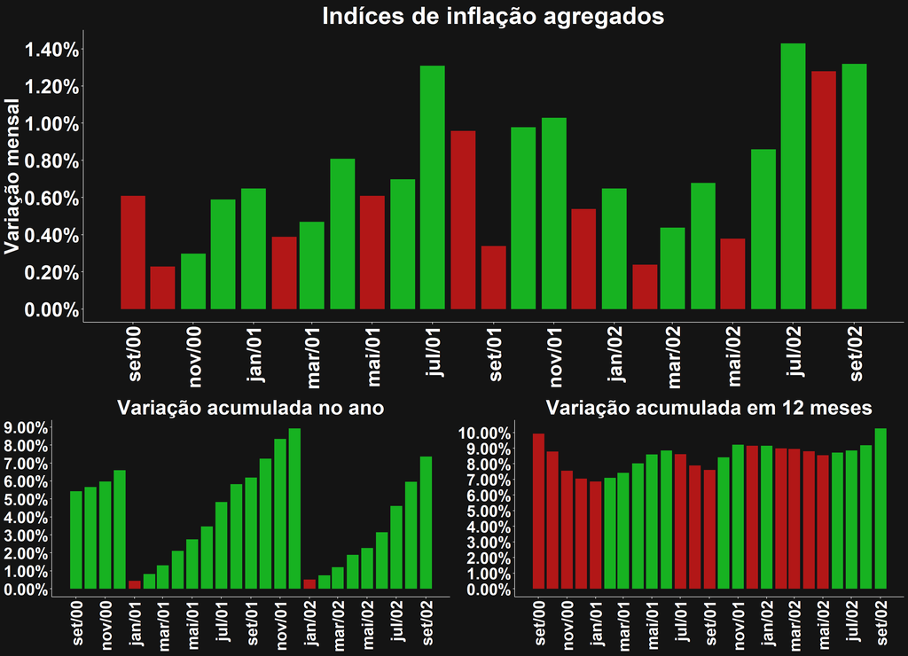

Índices selecionados para a média: IPCA, INPC e IGP-M.

# IPCA

O Indíce de Preços ao Consumidor Amplo (IPCA) variou 0.72% em setembro, valor superior ao mesmo período do ano anterior quando apresentou uma taxa de 0.28%. Com esse resultado o indíce acumula no ano uma variação positiva de 5.6%, e em 12 meses uma variação positiva de 7.93%.

|  | 09/2001 | 08/2002 | 09/2002 |
| --- | --- | --- | --- |
| Variação mensal | 0.28% | 0.65% | 0.72% |
| Variação acumulada no ano | 5.35% | 4.85% | 5.6% |
| Variação acumulada em 12 meses | 6.46% | 7.46% | 7.93% |

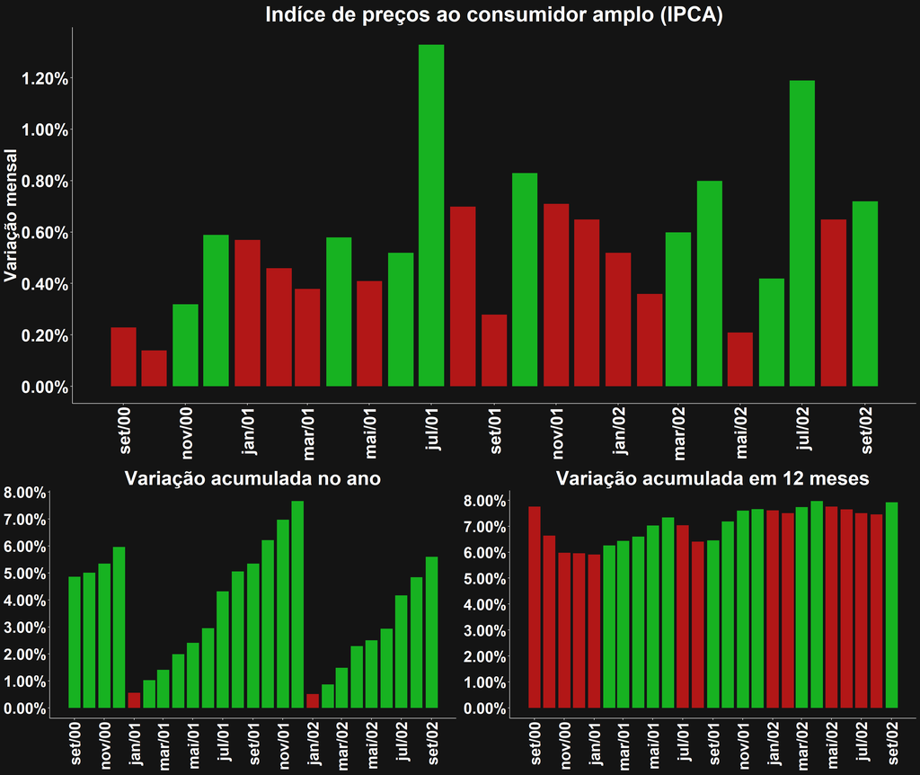

Os grupos que tiveram maior resultado positivo foram Alimentação e bebidas (1.96%) e Artigos de residência (1.73%), e negativo Habitação (-0.39%) e Comunicação (0.11%).

|  | Variação mensal | Variação acumulada no ano | Peso mensal |
| --- | --- | --- | --- |
| Alimentação e bebidas | 1.96% | 5.66% | 22.14% |
| Habitação | -0.39% | 8.87% | 16.73% |
| Artigos de residência | 1.73% | 5.15% | 5.63% |
| Vestuário | 0.55% | 5.49% | 5.38% |
| Transportes | 0.34% | 2.44% | 21.5% |
| Saúde e cuidados pessoais | 0.64% | 5.65% | 10.64% |
| Despesas pessoais | 0.61% | 4.44% | 9.4% |
| Educação | 0.4% | 7.74% | 4.89% |
| Comunicação | 0.11% | 11.14% | 3.69% |

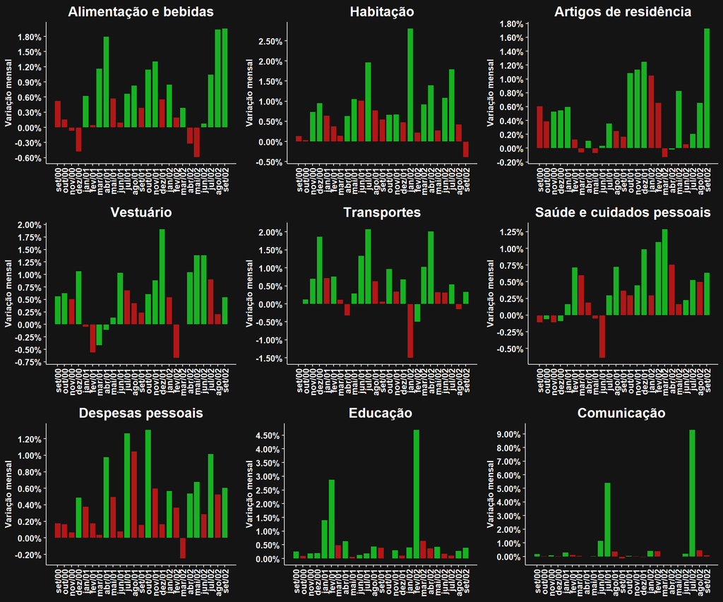

A nível de sub-itens os que mais influenciaram positivamente no resultado em relação ao seu peso foram Arroz (7.02%%) e Óleo de soja (14.23%%), e negativamente Gás de botijão (-7.61%%) e Batata-inglesa (-12.94%%).

|  | Variação mensal | Variação acumulada no ano | Peso mensal |
| --- | --- | --- | --- |
| Arroz | 7.02% | 2.87% | 0.73% |
| Frango | 5.26% | -1.32% | 0.77% |
| Pão francês | 2.68% | 18.72% | 1.54% |
| Óleo de soja | 14.23% | 37.05% | 0.35% |

|  | Variação mensal | Variação acumulada no ano | Peso mensal |
| --- | --- | --- | --- |
| Automóvel novo | -0.28% | -1.59% | 3.22% |
| Batata-inglesa | -12.94% | 11.64% | 0.15% |
| Feijão - carioca (rajado)) | -3.72% | 35.13% | 0.3% |
| Gás de botijão | -7.61% | 23.77% | 1.71% |

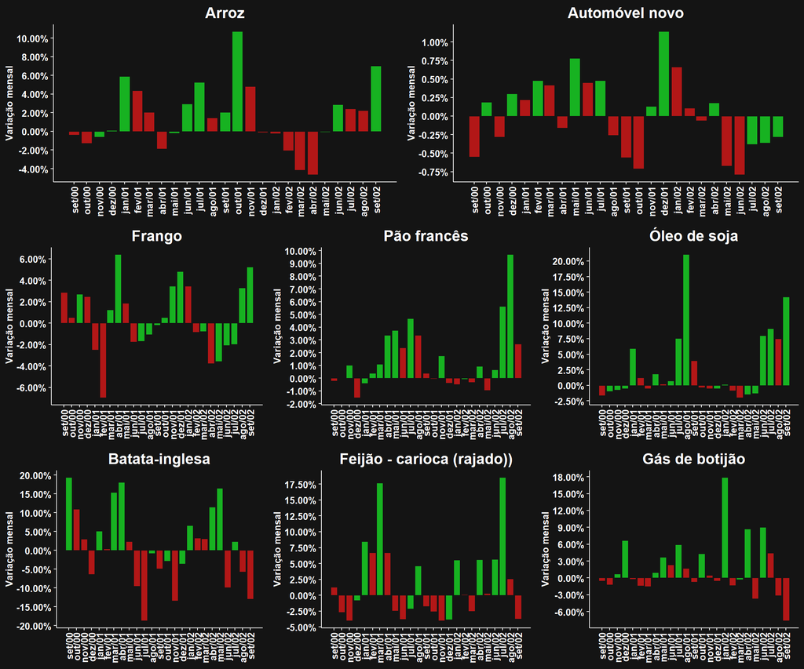

# INPC

O Indíce Nacional de Preços ao Consumidor (INPC) variou 0.83% em setembro, valor superior ao mesmo período do ano anterior quando apresentou uma taxa de 0.44%. Com esse resultado o indíce acumula no ano uma variação positiva de 6.39%, e em 12 meses uma variação positiva de 9.58%.

|  | 09/2001 | 08/2002 | 09/2002 |
| --- | --- | --- | --- |
| Variação mensal | 0.44% | 0.86% | 0.83% |
| Variação acumulada no ano | 6.26% | 5.51% | 6.39% |
| Variação acumulada em 12 meses | 7.32% | 9.16% | 9.58% |

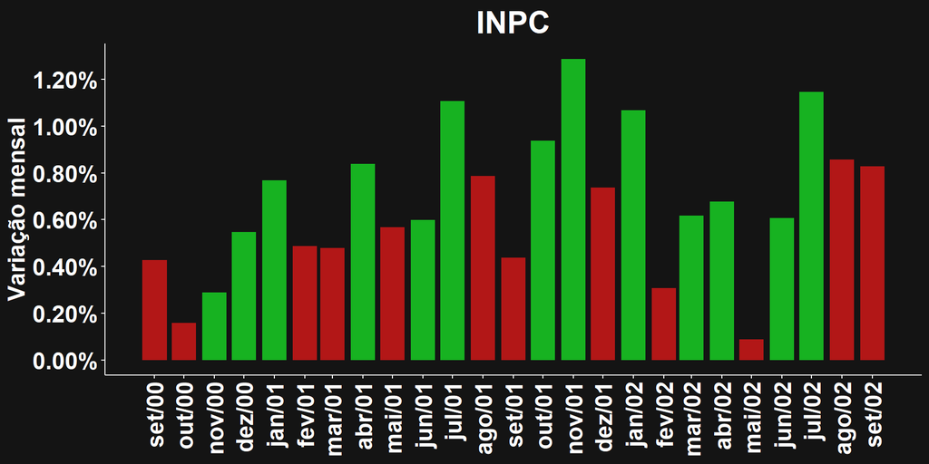

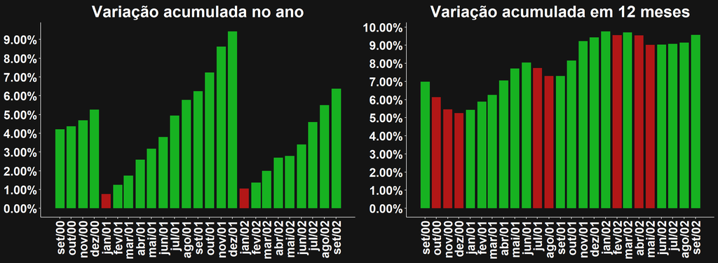

# IGP-M

O Indíce Geral de Preços de Mercado (IGP-M) variou 2.4% em setembro, valor superior ao mesmo período do ano anterior quando apresentou uma taxa de 0.31%. Com esse resultado o indíce acumula no ano uma variação positiva de 10.14%, e em 12 meses uma variação positiva de 13.32%.

|  | 09/2001 | 08/2002 | 09/2002 |
| --- | --- | --- | --- |
| Variação mensal | 0.31% | 2.32% | 2.4% |
| Variação acumulada no ano | 7.01% | 7.56% | 10.14% |
| Variação acumulada em 12 meses | 9.08% | 11.01% | 13.32% |

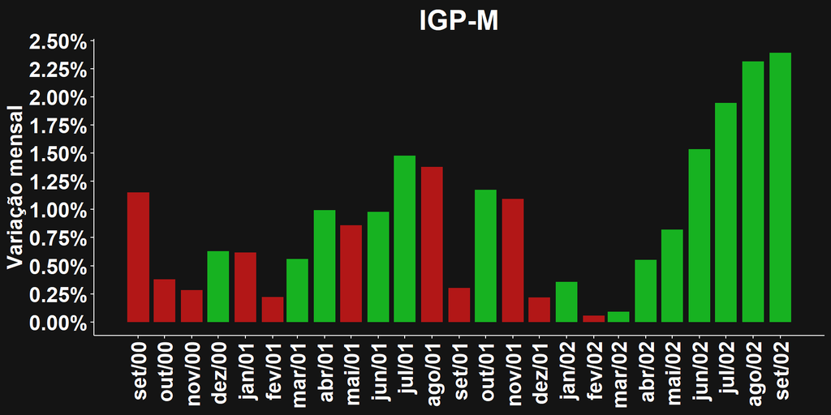

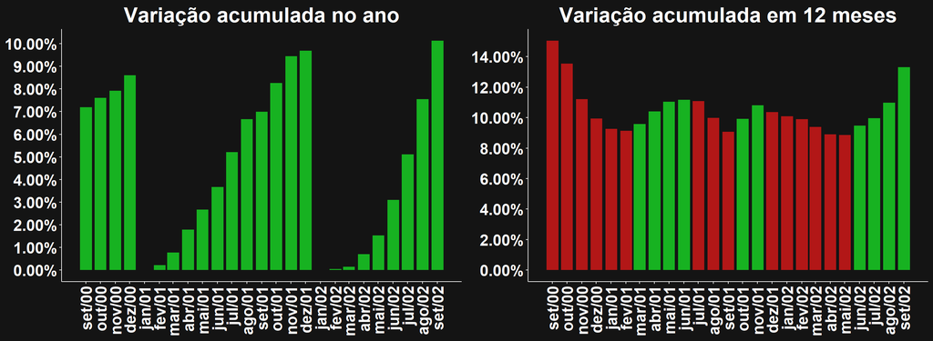

# IGP-DI

O Indíce Geral de Preços - Disponibilidade Interna (IGP-DI) variou 2.64% em setembro, valor superior ao mesmo período do ano anterior quando apresentou uma taxa de 0.38%. Com esse resultado o indíce acumula no ano uma variação positiva de 11.39%, e em 12 meses uma variação positiva de 14.28%.

|  | 09/2001 | 08/2002 | 09/2002 |
| --- | --- | --- | --- |
| Variação mensal | 0.38% | 2.36% | 2.64% |
| Variação acumulada no ano | 7.28% | 8.52% | 11.39% |
| Variação acumulada em 12 meses | 9.45% | 11.76% | 14.28% |

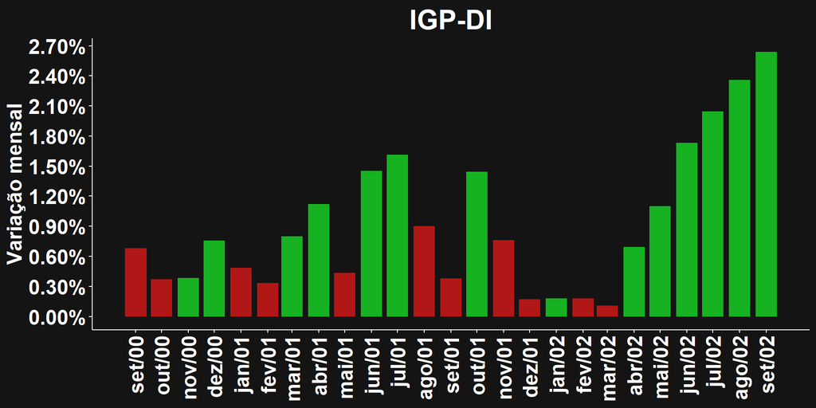

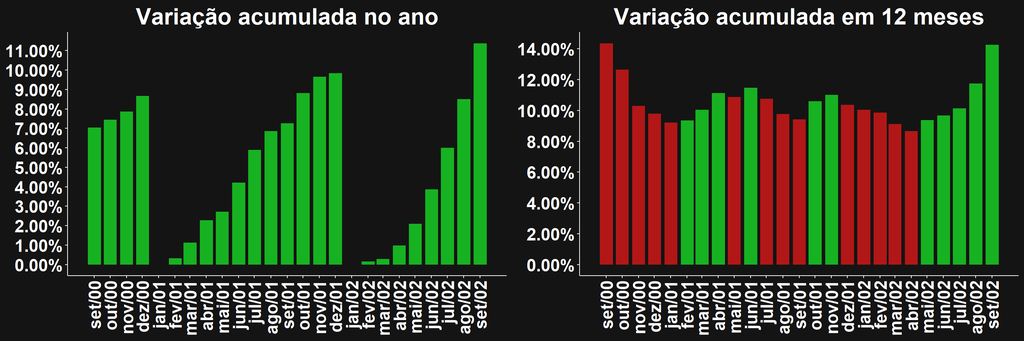

O Indíce de Preços de Atacado (IPA), integrante do IGP-DI com peso de 60%, apresentou variação de 3.84% em setembro, valor superior ao mesmo período do ano anterior quando apresentou uma taxa de 0.48%. Com esse resultado o indíce acumula no ano uma variação positiva de 0.15%, e em 12 meses uma variação positiva de 0.18%.

|  | 09/2001 | 08/2002 | 09/2002 |
| --- | --- | --- | --- |
| Variação mensal | 0.48% | 3.32% | 3.84% |
| Variação acumulada no ano | 0.09% | 0.11% | 0.15% |
| Variação acumulada em 12 meses | 0.11% | 0.14% | 0.18% |

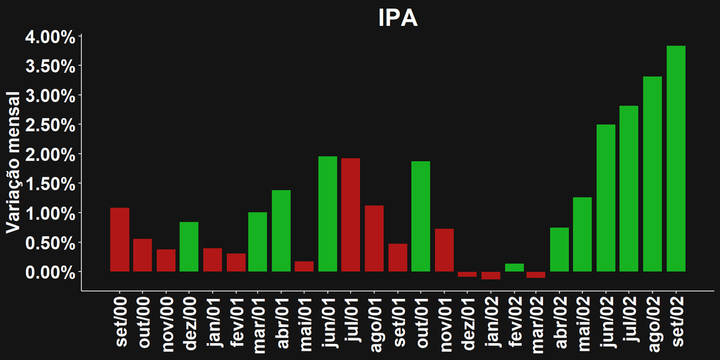

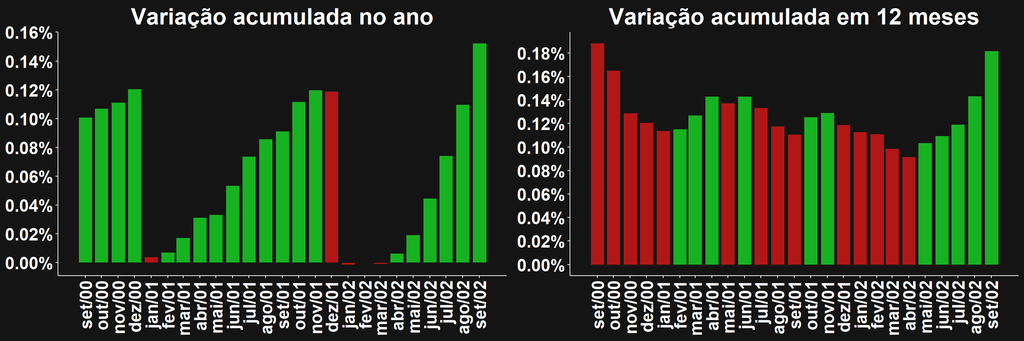

O Indíce de Preços ao Consumidor (IPC), integrante do IGP-DI com peso de 30%, apresentou variação de 0.66% em setembro, valor superior ao mesmo período do ano anterior quando apresentou uma taxa de 0.12%. Com esse resultado o indíce acumula no ano uma variação positiva de 4.65%, e em 12 meses uma variação positiva de 7.89%.

|  | 09/2001 | 08/2002 | 09/2002 |
| --- | --- | --- | --- |
| Variação mensal | 0.12% | 0.76% | 0.66% |
| Variação acumulada no ano | 4.86% | 3.96% | 4.65% |
| Variação acumulada em 12 meses | 6.64% | 7.31% | 7.89% |

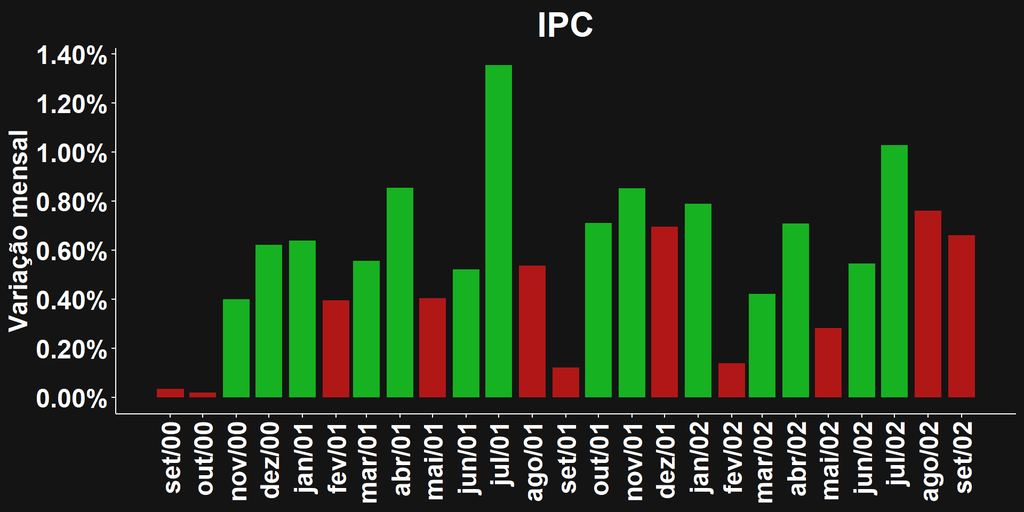

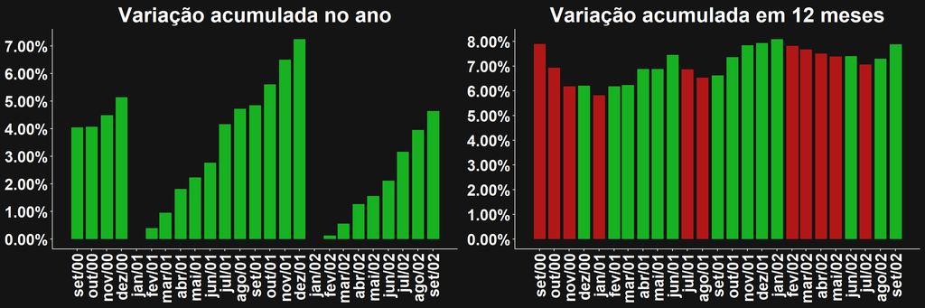

O Indíce Nacional de Custos de Construção (INCC), integrante do IGP-DI com peso de 10%, apresentou variação de 0.71% em setembro, valor superior ao mesmo período do ano anterior quando apresentou uma taxa de 0.55%. Com esse resultado o indíce acumula no ano uma variação positiva de 6.73%, e em 12 meses uma variação positiva de 9.28%.

|  | 09/2001 | 08/2002 | 09/2002 |
| --- | --- | --- | --- |
| Variação mensal | 0.55% | 1% | 0.71% |
| Variação acumulada no ano | 6.09% | 5.98% | 6.73% |
| Variação acumulada em 12 meses | 8.19% | 9.11% | 9.28% |

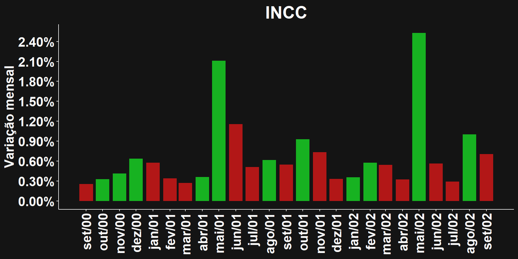

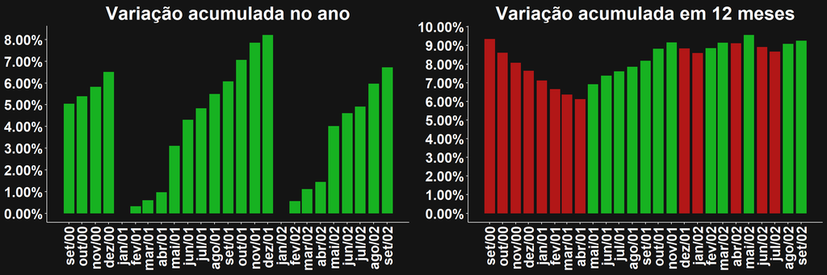

# Estatísticas

As estatísticas descritivas a seguir são feitas com base nos últimos 48 meses, e tem como objetivo possibilitar a avaliação do resultado observado em comparação aos períodos anteriores.

|  | Minimo | 1 Quartil | Mediana | Media | 3 Quartil | Maximo | Desvio Padrão |
| --- | --- | --- | --- | --- | --- | --- | --- |
| IPCA | -0.12% | 0.31% | 0.56% | 0.57% | 0.71% | 1.61% | 0.38% |
| INPC | -0.18% | 0.31% | 0.6% | 0.6% | 0.84% | 1.39% | 0.4% |
| IGP-M | -0.32% | 0.34% | 0.85% | 1.01% | 1.54% | 3.61% | 0.86% |
| IGP-DI | -0.34% | 0.36% | 0.92% | 1.03% | 1.5% | 4.44% | 0.91% |
| IPA | -0.82% | 0.28% | 1.11% | 1.34% | 2.06% | 6.99% | 1.41% |
| IPC | -0.19% | 0.28% | 0.55% | 0.58% | 0.81% | 1.91% | 0.42% |
| INCC | -0.05% | 0.36% | 0.56% | 0.66% | 0.86% | 2.53% | 0.46% |

Levando em consideração o desvio padrão de cada indíce, proporcionalmente os que mais se afastaram da média foram o IPA, o IGP-DI e o IGP-M.

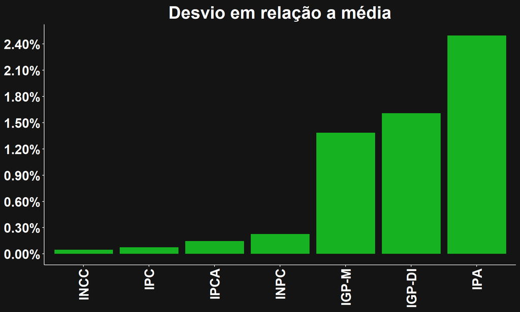

**João Victor Gomes**  
**jvg.santana@gmail.com**  
**[linkedin.com/in/jvictorgomes](https://www.linkedin.com/in/jvictorgomes/)**